# Lab 10: ANOVA

Ednita J Tavarez-Jimenez

## ANOVA by Hand

**Q1: Submit the code you used to build your ANOVA by hand. Make sure you use the code template so that you use the same variable names as those which we’ll use for the grading.**

```r
require(here)
rm(list = ls())

rope = read.csv(here("data", "rope.csv"))
rope$rope.type = factor(rope$rope.type)
rope_names <- levels(rope$rope.type)
rope$rope.type
```

```
##   [1] VEL   BLAZE BLAZE BLAZE VEL   SB    VEL   XTC   XTC   VEL   PI    BLAZE
##  [13] XTC   BS    XTC   VEL   BLAZE SB    BLAZE BLAZE BS    VEL   VEL   SB
##  [25] SB    SB    BS    BS    SB    SB    SB    BLAZE BLAZE VEL   VEL   XTC
##  [37] XTC   VEL   BS    PI    BS    SB    SB    XTC   BS    BS    PI    PI
##  [49] BLAZE PI    XTC   XTC   BLAZE PI    BS    BLAZE PI    PI    XTC   VEL
##  [61] XTC   VEL   BS    PI    XTC   VEL   VEL   VEL   BS    PI    SB    PI
##  [73] SB    BLAZE BLAZE XTC   BS    BLAZE VEL   SB    BS    XTC   BS    BLAZE
##  [85] BS    SB    PI    SB    BLAZE BLAZE VEL   XTC   XTC   BLAZE PI    SB
##  [97] XTC   BLAZE PI    PI    BS    VEL   VEL   XTC   BS    PI    BLAZE SB
## [109] BS    VEL   SB    PI    BS    XTC   PI    SB    XTC   BS    SB    PI
## [121] PI
## Levels: BLAZE BS PI SB VEL XTC
```

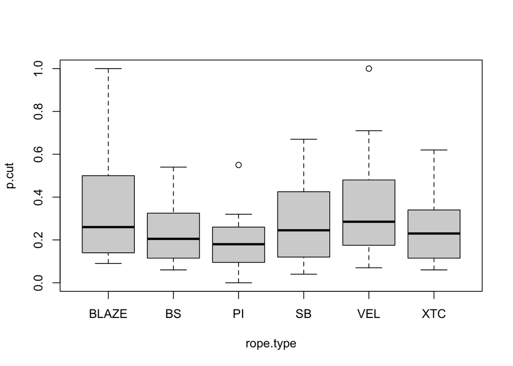

```r
n_obs = nrow(rope)

boxplot(p.cut ~ rope.type, data = rope)
```

```r
n_groups = length(rope_names)

#SS Tot for p.cut
mean_pcut <- mean(rope$p.cut)
p_resids <- rope$p.cut - mean_pcut
squ_resids <- p_resids^2
sum_presids <- sum(squ_resids)
ss_tot = sum(squ_resids)

agg_resids <- aggregate(
  x = rope$p.cut,
  by = list(rope$rope.type),
  FUN = function(x) x-mean(x))
str(agg_resids)
```

```
## 'data.frame':    6 obs. of  2 variables:
##  $ Group.1: Factor w/ 6 levels "BLAZE","BS","PI",..: 1 2 3 4 5 6
##  $ x      :List of 6
##   ..$ : num  0.633 0.633 0.623 0.173 0.143 ...
##   ..$ : num  0.303 0.223 0.193 0.183 0.093 ...
##   ..$ : num  0.363 0.133 0.113 0.103 0.083 0.063 0.053 0.053 0.033 -0.007 ...
##   ..$ : num  0.398 0.238 0.178 0.168 0.168 0.138 0.118 0.118 0.048 0.038 ...
##   ..$ : num  0.65 0.36 0.3 0.22 0.16 ...
##   ..$ : num  0.3545 0.3145 0.2745 0.2545 0.0745 ...
```

```r
agg_sum_sq_resids <- aggregate(
  x = rope$p.cut,
  by = list(rope$rope.type),
  FUN = function(x) sum((x - mean(x))^2))
str(agg_sum_sq_resids)
```

```
## 'data.frame':    6 obs. of  2 variables:
##  $ Group.1: Factor w/ 6 levels "BLAZE","BS","PI",..: 1 2 3 4 5 6
##  $ x      : num  1.808 0.405 0.312 0.633 1.129 ...
```

```r
ss_within <- sum(agg_sum_sq_resids$x)

ss_among = ss_tot - ss_within

df_tot = n_obs - 1
df_within = n_obs - n_groups
df_among = n_groups - 1

ms_among  =  ss_among / (n_groups - 1)
ms_within = ss_within / (n_obs - n_groups)

f_ratio =  ms_among / ms_within
f_pval =  1 - pf(f_ratio, df_among, df_within)


# number comparison tolerance
digits_check = 5

# Build the reference model using R functions
fit_1 = lm(p.cut ~ rope.type, data=rope)
anova(fit_1)
```

```
## Analysis of Variance Table
##
## Response: p.cut
##            Df Sum Sq  Mean Sq F value  Pr(>F)
## rope.type   5 0.4729 0.094577  2.2312 0.05582 .
## Residuals 115 4.8747 0.042389
## ---
## Signif. codes:  0 '***' 0.001 '**' 0.01 '*' 0.05 '.' 0.1 ' ' 1
```

```r
anova_fit_1 = anova(fit_1)

anova_fit_1$"Sum Sq"
```

```
## [1] 0.4728867 4.8746836
```

```r
# Check degrees of freedom
anova_fit_1$Df == c(df_among, df_within)
```

```
## [1] TRUE TRUE
```

```r
# Check sums of squares
round(anova_fit_1$`Sum Sq`, digits = digits_check) == round(c(ss_among, ss_within), digits = digits_check)
```

```
## [1] TRUE TRUE
```

```r
# Check mean squares
round(anova_fit_1$`Mean Sq`, digits = digits_check) == round(c(ms_among, ms_within), digits = digits_check)
```

```
## [1] TRUE TRUE
```

```r
# Check the F-ratio
round(anova_fit_1$`F value`[1], digits = digits_check) == round(f_ratio, digits = digits_check)
```

```
## [1] TRUE
```

```r
# Check the F test statistic p-value
round(anova_fit_1$`Pr(>F)`[1], digits = digits_check) == round(f_pval, digits = digits_check)
```

```
## [1] TRUE
```

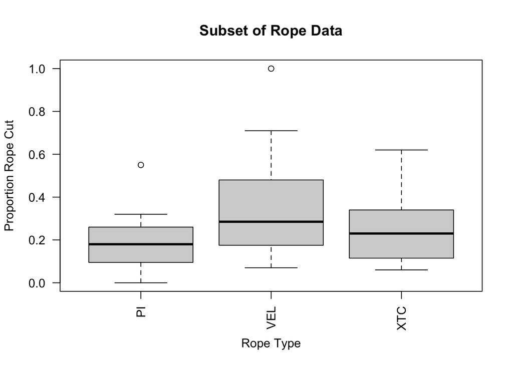

```r
rope2 = droplevels(
  subset(
    rope,
    rope.type %in% c("PI", "VEL", "XTC"))
)

boxplot(
  p.cut ~ rope.type,
  data = rope2,
  las = 2,
  xlab = "",
  ylab = "Proportion Rope Cut",
  main = "Subset of Rope Data")
mtext("Rope Type", side = 1, line = 3)
```

```r
fit_rope_2 = lm(p.cut ~ rope.type, data=rope2)

rope2_hsd = TukeyHSD(aov(fit_rope_2))

class(rope2_hsd)
```

```
## [1] "TukeyHSD"  "multicomp"
```

```r
round(rope2_hsd$rope.type, digits = 4)
```

```
##            diff     lwr    upr  p adj
## VEL-PI   0.1630  0.0194 0.3066 0.0224
## XTC-PI   0.0785 -0.0651 0.2221 0.3924
## XTC-VEL -0.0845 -0.2281 0.0591 0.3394
```

## Model Assumptions: Constant Variance

**Q2: Examine the conditional box plot in the Partitioning Variance: Within-Group section of the walk-through. Based on the figure, do you think there are equal variances among the groups?**

I do not think there are equal variances among the groups.

**Q3: Conduct a Bartlett test to assess the homogeneity of variances of the percent cut among the rope type groups.**

```r
bartlett.test(p.cut ~ rope.type, data = rope)
```

```
##
##  Bartlett test of homogeneity of variances
##
## data:  p.cut by rope.type
## Bartlett's K-squared = 19.687, df = 5, p-value = 0.00143
```

**Q4: Given your graphical assessment (question 2) and the Bartlett test, do you think an ANOVA-type analysis is appropriate on the raw data? Explain why or why not.**

the p-value is under .05 therefore we reject the null hypothesis because there are variances within the variances.

## Model coefficients and group means

**Q5: Which rope type is the base case?**

Blaze is the base case

```r
fit_rope_1 = lm(p.cut ~ rope.type, data = rope)
summary(fit_rope_1)
```

```
##
## Call:
## lm(formula = p.cut ~ rope.type, data = rope)
##
## Residuals:
##     Min      1Q  Median      3Q     Max
## -0.2800 -0.1500 -0.0355  0.1030  0.6500
##
## Coefficients:
##              Estimate Std. Error t value Pr(>|t|)
## (Intercept)   0.36714    0.04493   8.172 4.45e-13 ***
## rope.typeBS  -0.13014    0.06433  -2.023  0.04538 *
## rope.typePI  -0.18014    0.06433  -2.800  0.00599 **
## rope.typeSB  -0.09514    0.06433  -1.479  0.14186
## rope.typeVEL -0.01714    0.06433  -0.266  0.79033
## rope.typeXTC -0.10164    0.06433  -1.580  0.11683
## ---
## Signif. codes:  0 '***' 0.001 '**' 0.01 '*' 0.05 '.' 0.1 ' ' 1
##
## Residual standard error: 0.2059 on 115 degrees of freedom
## Multiple R-squared:  0.08843,    Adjusted R-squared:  0.0488
## F-statistic: 2.231 on 5 and 115 DF,  p-value: 0.05582
```

**Q6: What is the mean percent cut of the base case rope? Show your calculation using value(s) from the model coefficient table.**

The mean percent cut of the base case rope is 0.36714

**Q7: What is the mean percent cut rope type XTC? Show your calculation using value(s) from the model coefficient table.**

The mean percent cut rope type XTC is .2655

```r
.36714 - .10164
```

```
## [1] 0.2655
```

## Model Assumptions: Residual Normality

**Q8: Use the residuals() function to retrieve the residuals from your model and perform an overall normality test. Report the p-value.**

The p- value is 7.238e-07

```r
residuals(fit_rope_1)
```

[output not shown]

```r
shapiro.test(residuals(fit_rope_1))
```

```
##
##  Shapiro-Wilk normality test
##
## data:  residuals(fit_rope_1)
## W = 0.91144, p-value = 7.238e-07
```

**Q9: Do your model residuals meet the normality assumption, and how do you know?**

**Q10: Perform normality tests on the residuals within each group. How many groups meet the normality assumption?**

```r
res_within <- sapply(agg_resids$x, function(x) shapiro.test(x)$p)
```

**Q11: Given the results of your tests for residual normality, do you think that a one-way Analysis of Variance is appropriate for this dataset?**

## Post-Hoc Testing

**Q12: Create a conditional boxplot of the female penguins: body mass conditioned on species.**

```r
require(palmerpenguins)
```

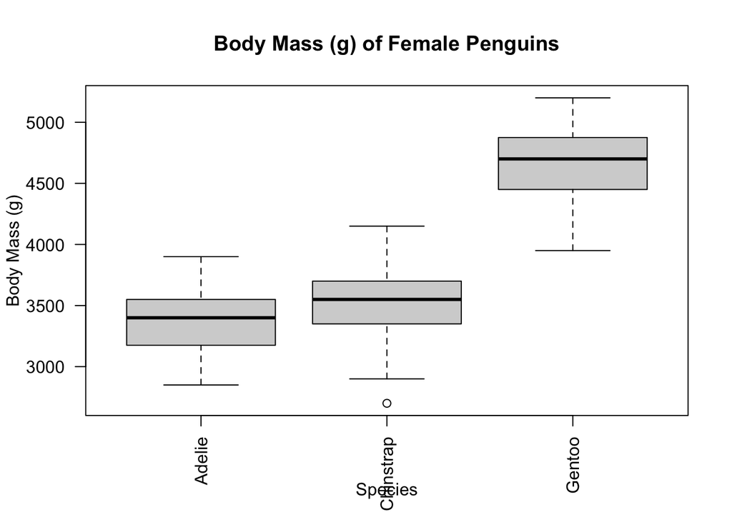

```r
pen_fem = subset(penguins, sex == "female")

boxplot(
  body_mass_g ~ species,
  data = pen_fem,
  las = 2,
  xlab = "Species",
  ylab = "Body Mass (g)",
  main = "Body Mass (g) of Female Penguins")
```

**Q13: Based on the boxplot, do you anticipate any problems with residual normality, or homogeneity of variances? Why or why not?**

I anticipate there isn’t going to be any problems in the residual normality or the homogeneity of variances because the independent groups have an equal variance.

**Q14: Conduct a Bartlett test for homogeneity of variances of body mass grouped by species. Hint: use the formula notation. Report the p-value. Is the homogeneity assumption met? Why or why not?**

The p-value is 0.9056, therefore we accept the null hypothesis because there are no variances within between the species.

```r
bartlett.test(body_mass_g ~ species, data = pen_fem)
```

```
##
##  Bartlett test of homogeneity of variances
##
## data:  body_mass_g by species
## Bartlett's K-squared = 0.19828, df = 2, p-value = 0.9056
```

**Q15: Fit a linear model of body mass (the response) and species (the predictor) using the female penguin data. Conduct a test for normality of the residuals. Report the p-value. Is the residual normality assumption met? Why or why not?**

The p-value is .3639. The residual assumption is met because the p-valus is over .05 which means that is insufficient evidence to question the assertion and so you should treat the assertion as reasonable.

```r
pen_fem_1 = lm(body_mass_g ~ species, data = pen_fem)

summary(pen_fem_1)
```

```
##
## Call:
## lm(formula = body_mass_g ~ species, data = pen_fem)
##
## Residuals:
##     Min      1Q  Median      3Q     Max
## -827.21 -193.84   20.26  181.16  622.79
##
## Coefficients:
##                  Estimate Std. Error t value Pr(>|t|)
## (Intercept)       3368.84      32.42 103.908  < 2e-16 ***
## speciesChinstrap   158.37      57.52   2.754  0.00657 **
## speciesGentoo     1310.91      48.72  26.904  < 2e-16 ***
## ---
## Signif. codes:  0 '***' 0.001 '**' 0.01 '*' 0.05 '.' 0.1 ' ' 1
##
## Residual standard error: 277 on 162 degrees of freedom
## Multiple R-squared:  0.8292, Adjusted R-squared:  0.8271
## F-statistic: 393.2 on 2 and 162 DF,  p-value: < 2.2e-16
```

```r
residuals(pen_fem_1)
```

[output not shown]

```r
shapiro.test(residuals(pen_fem_1))
```

```
##
##  Shapiro-Wilk normality test
##
## data:  residuals(pen_fem_1)
## W = 0.99077, p-value = 0.3639
```

**Q16: Conduct a Tukey HSD post-hoc test on your model. Which pair or pairs of species have significantly different body masses?**

```r
pen_fem_hsd = TukeyHSD(aov(pen_fem_1))

class(pen_fem_hsd)
```

```
## [1] "TukeyHSD"  "multicomp"
```

```r
round(pen_fem_hsd$species, digits = 4)
```

```
##                       diff       lwr       upr  p adj
## Chinstrap-Adelie  158.3703   22.3208  294.4197 0.0179
## Gentoo-Adelie    1310.9058 1195.6491 1426.1624 0.0000
## Gentoo-Chinstrap 1152.5355 1011.0062 1294.0648 0.0000
```

**Q17: Describe how your HSD rest results match, or do not match, the graphical insight from the conditional boxplot.**